# Семинары 10-11. Большая размерность. Регуляризация

Анна Ставнийчук

7-14 ноября 2022

annastavnychuk@gmail.com

# 1. Регуляризация

## 1.1 Что такое регуляризация?

**Зачем нужна регуляризация?**

- очень много ковариат, которые нужно как-то отобрать, а другие способы не подходят
- проблема мультиколинеарности
- снижение размерности
- переобучение
- фильтры
- информационные критерии Акаике и Шварца

Предположим, что мы находимся в ситуации мультиколинеарности.

- Строгая мультиколинеарность создает проблему неедиснтвенности МНК-оценок.
- При нестрогой мультиколинеарности оценки все еще являются несмещенными и асимптотически нормальными, однако стандартные ошибки в такой модели будут больше. Это приводит к широким доверительным интервалам и незначимым оценкам.

Тогда у нас есть 2 варианта, как с ней бороться. Первый – выбросить часть регрессоров, снизив дисперсию оценок и пожертвовав несмещенностью. Второй – использовать регуляризацию (МНК со штрафной функцией) – включение штрафа в сумму наименьших квадратов.

Исходная постановка МНК:

$$\begin{aligned}
&\min _{\hat{\beta}_j} ESS = \min _{\hat{\beta}_j} \sum_{i=1}^{n}
e_i^2 = \min _{\hat{\beta}_j} \sum_{i=1}^{n}
\left(y_{i}-\hat{y}_{i}\right)^{2} = \min _{\hat{\beta}_j}
\sum_{i=1}^{n} \left(y_{i}-\hat{\beta}_1 - \hat{\beta_2}\cdot x_i -
...\right)^{2}
\end{aligned}$$

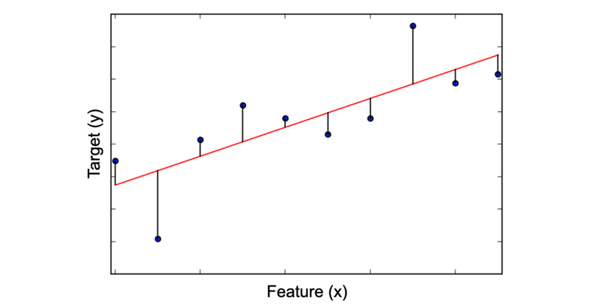

Регуляризация фактически является задачей Лагранжа, которую вы много раз решали. В исходную оптимизационную задачу мы добавляем дополнительное ограничение, чтобы оценки были не очень большими. Тогда $\lambda$ является множителем Лагранжа (но в этот раз для нас более важно, что это коэффициент регуляризации).

В общем виде постановка задачи регуляризации выглядит следующим образом:

$$\begin{aligned}
&\min _{\hat{\beta}_j} ESS + \text{штраф}
\end{aligned}$$

В зависимости от того, какую штрафную функцию мы используем, выделяют несколько основных видов регуляризации:

- Ридж-регрессия
- Регрессия лассо
- Метод эластичной сети

### 1.1.1 Ридж-регрессия (ridge)

Иногда еще называют L2 или регуляризация Тихонова (почему именно L2 можно почитать [тут](https://habr.com/ru/company/ods/blog/322076/)). В качестве функции штрафа используется сумма квадратов оценок коэффициентов:

$$\begin{aligned}
&\min _{\hat{\beta}_j}
\sum_{i=1}^{n}\left(y_{i}-\hat{y}_{i}\right)^{2}+\lambda\left(\hat{\beta}_{1}^{2}+\hat{\beta}_{2}^{2}+\ldots+\hat{\beta}_{k}^{2}\right)
\end{aligned}$$

$$\begin{aligned}
\begin{cases}
&\sum_{i=1}^{n}\left(y_{i}-\hat{y}_{i}\right)^{2} \rightarrow
\underset{\hat{\beta}_j}{\min} \\
&\hat{\beta}_{1}^{2}+\hat{\beta}_{2}^{2}+\ldots+\hat{\beta}_{k}^{2}
\leq t
\end{cases}
\end{aligned}$$
А такую задачу мы умеем решать графически!

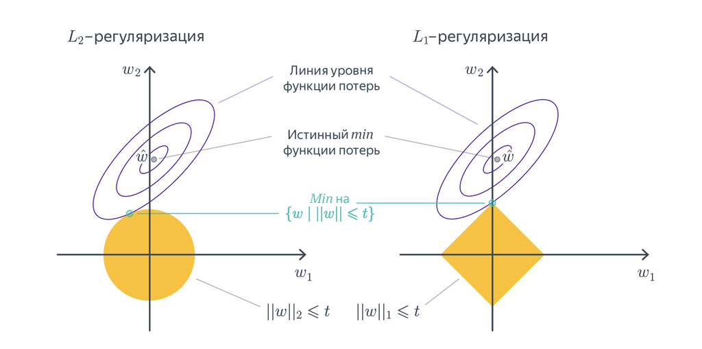

### 1.1.2 LASSO регрессия

Иногда еще называют L1 или регуляризация через манхэттенское расстояние. В качестве функции штрафа используется сумма модулей оценок коэффициентов:

$$\begin{aligned}
&\min _{\hat{\beta}_j}
\sum_{i=1}^{n}\left(y_{i}-\hat{y}_{i}\right)^{2}+\lambda\left(\left|\hat{\beta}_{1}\right|+\left|\hat{\beta}_{2}\right|+\ldots+\left|\hat{\beta}_{k}\right|\right)
\end{aligned}$$

$$\begin{aligned}
\begin{cases}
&\sum_{i=1}^{n}\left(y_{i}-\hat{y}_{i}\right)^{2} \rightarrow
\underset{\hat{\beta}_j}{\min} \\
&\left|\hat{\beta}_{1}\right|+\left|\hat{\beta}_{2}\right|+\ldots+\left|\hat{\beta}_{k}\right|
\leq t
\end{cases}
\end{aligned}$$

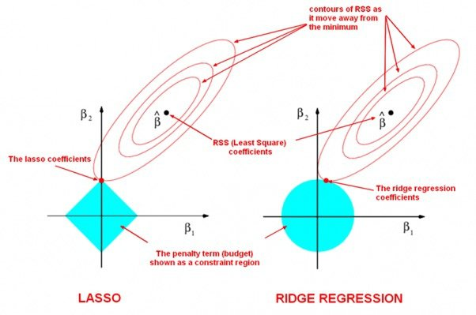

### 1.1.3 Метод эластичной сети (Elastic Net)

Комбинацией лассо и ридж регрессий является метод эластичной сети.

$$\min _{\hat{\beta}_j}
\sum_{i=1}^{n}\left(y_{i}-\hat{y}_{i}\right)^{2}+\lambda_{1}
\sum_{j=1}^{k}\left|\hat{\beta}_{j}\right|+\lambda_{2} \sum_{j=1}^{k}
\hat{\beta}_{j}^{2}$$

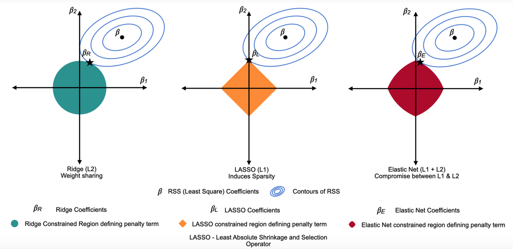

## 1.2 Как выбрать коэффициент регуляризации?

Это делают с помощью кросс валидации (cross validation). Как правило, почти всегда, когда говорят о кросс-валидации, имеют в виду метод k-Fold.

### 1.2.1 k-Fold

- Выбираем $m$ штук $\lambda$, которые будем проверять;
- Фиксируем одну из $\lambda$;
- Вся выборка разделяется на k частей (k - произвольное число, часто от 5 до 10, на картинке внизу как раз 10). В машинке эти части называют фолдами;
- Далее происходит k итераций, во время каждой из которых один фолд выступает в роли тестового множества, а объединение остальных — в роли обучающего. Модель оценивается на k−1 фолде и тестируется на оставшемся. На каждом шаге итерации на тестовом фолде считается метрика качества подгонки, например, MSE (mean squared error);
- Далее k получившихся метрик агрегируются в финальный общий показатель качества модели для зафиксированной $\lambda$, например считается средняя MSE из k штук;
- Повторяем процедуру для всех $m$ штук $\lambda$;
- Выбираем $\lambda$ с минимальным финальным общим показателем $\overline{MSE}$.

$$MSE_j = \frac{1}{n_j}\sum \left(y_i - \hat{m}^{(-j)}(x_i)\right)^2$$

$$\overline{MSE}_{\lambda_m} = \frac{1}{k}\sum_{j=1}^k MSE_j$$
$$\lambda^* = \underset{\lambda_m}{argmin}\{\overline{MSE}_{\lambda_1},
... , \overline{MSE}_{\lambda_m}\}$$

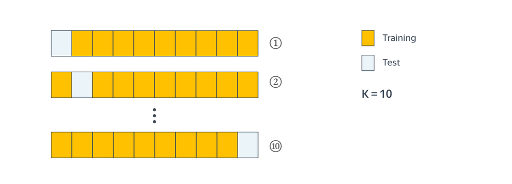

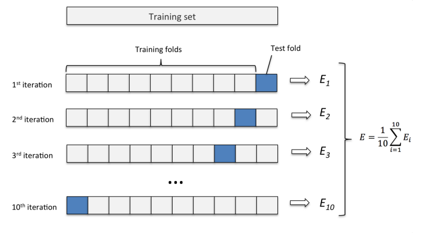

### 1.2.1 Кросс-валидация временных рядов

Кросс-валидация моделей для временных рдов осложняется тем, что данные не должны пересекаться по времени: обучающие данные должны идти до тестовых. С учётом этих особенностей фолды в кросс-валидации для временных рядов располагаются вдоль временной оси так, как показано на следующей картинке:

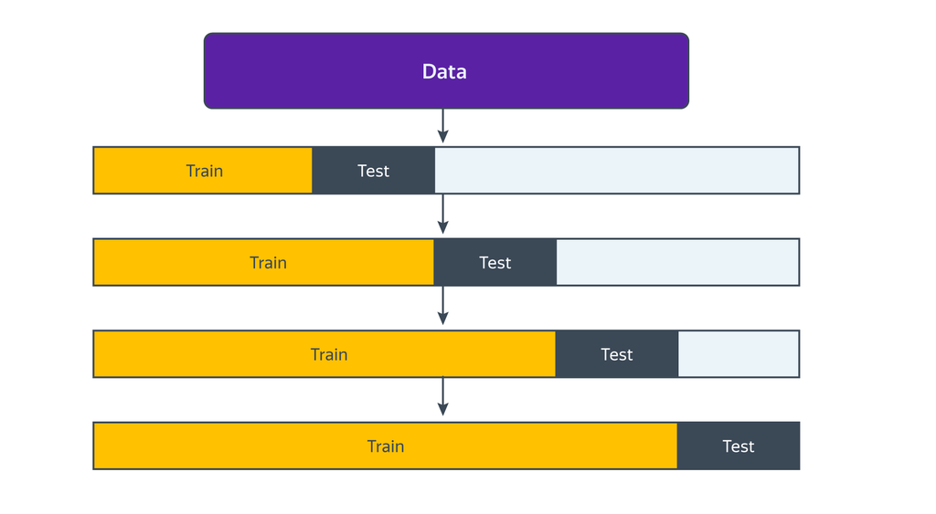

## 1.3 Фильтр Ходрика-Прескота

По сути формазизация задачи выделения тренда с помощью фильтра Ходрика-Прескота является регуляризацией. Мы ищем компромисс между точностью описания временного ряда и его гладкостью (тренд предыдущего периода должен быть похож на тренд текущего):

$$\begin{aligned}
&\min_{g}
\underbrace{\sum_{t=1}^{T}\left(y_{t}-g_{t}\right)^{2}}_{\text{точность
описания}}+ \lambda\underbrace{\sum_{t=2}^{T-1}
\left[\left(g_{t+1}-g_t\right)-(g_t-g_{t-1})\right]^2}_{\text{гладкость
тренда}}
\end{aligned}$$
где $y_t$ – изучаемый временной ряд, $g_t$ – выделяемый тренд.

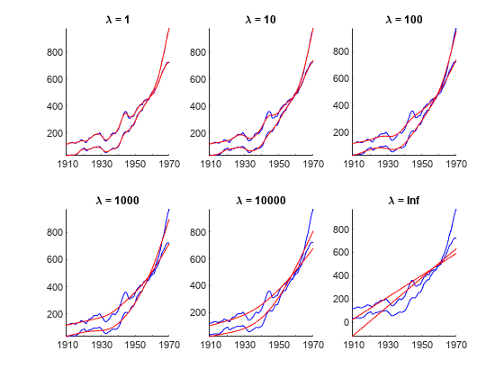

# 2. Double LASSO

Живем в ситуации unconfoundedness $T_i \perp Y_{i1}, Y_{i0} | X_i$

## 2.1.Double selection

- Выбираем набор переменных с помощью LASSO
  - $Y\sim X$, получаем $\hat{\beta}_j^Y \neq 0$, оставляем эти иксы;
- Выбираем набор переменных с помощью LASSO
  - $T\sim X$, получаем $\hat{\beta}_j^T \neq 0$, оставляем эти иксы;
- Финальная регрессия (иногда называют post LASSO OLS)
  - $Y \sim T + \text{отобранные на прошлых шагах } X$, получаем $\hat{\tau}^{DL}=\hat{ATE}$

## 2.2 Partialling-out

По теореме Фриша-Ву-Ловелла то же самое можно сделать с помощью другой процедуры.

- Выбираем набор переменных с помощью LASSO
  - $Y\sim X$, получаем $\hat{\beta}_j^Y \neq 0$, оставляем эти иксы;
- Оцениваем регрессию $Y\sim X$ только на те $X$, которые отобрали на прошлом шаге, где $\hat{\beta}_j^Y \neq 0$. Получаем остатки модели $e_i^Y$;
- Выбираем набор переменных с помощью LASSO
  - $T\sim X$, получаем $\hat{\beta}_j^T \neq 0$, оставляем эти иксы;
- Оцениваем регрессию $T\sim X$ только на те $X$, которые отобрали на прошлом шаге, где $\hat{\beta}_j^T \neq 0$. Получаем остатки модели $e_i^T$;
- Финальная регрессия остатков на остатки
  - $e_i^Y \sim e_i^T$, получаем $\hat{\tau}^{DL}=\hat{ATE}$

# 3. Пример

В качестве примера использования регуляризации мы воспользуется работой [(Veterinarov, Ivanov, 2018)](http://dx.doi.org/10.2139/ssrn.3249624), которые изучали цену этнической дискриминации для арендодателей на рынке жилья. Авторы пытались оценить эффект наличия в объявлении дискриминирующих по этническому признаку формулировак на стоимость аренды квартир. Оказалось, что этническая дискриминация связана со значительным снижением цены.

Импортируем данные:

```r
data <- read.csv("table_cian_mos_ecm.csv")
```

Набор данных включает следующие переменные:

- `price` – цена аренды квартиры в рублях;
- `total_area` – общая площадь квартиры в квадратных метрах;
- `discrim_proxy` – наличие дискриминирующего текста в описании объявления;
- `*_rajon` – набор бинарных переменных, соотвествующих районам Москвы, где расположена квартира;
- `first_floor` – бинарная переменная, равная единице, если квартира расположена на первом этаже;
- `*_rooms` – набор бинарных переменных, соотвествующих количеству комнат в квартире;
- `starii_fond` – бинарная переменная, равная единице, если квартира принадлежит к старому жилому фонду;
- `blochnii` – бинарная переменная, равная единице, если квартира находится в блочном доме;
- `derevjannii` – бинарная переменная, равная единице, если квартира находится в деревянном доме;
- `kirpichnii` – бинарная переменная, равная единице, если квартира находится в кирпичном доме;
- `monolitnii` – бинарная переменная, равная единице, если квартира находится в монолитном доме;
- `panelnii` – бинарная переменная, равная единице, если квартира находится в кирпичном доме;
- `stalinskii` – бинарная переменная, равная единице, если квартира находится в сталинском доме;
- `repair` – бинарная переменная, равная единице, если в квартире сделан ремонт;
- `four_and_over_rooms` – бинарная переменная, равная единице, если в квартире четыре и более комнат.

Создадим логарифмы площади и цены:

```r
data$log_total_area <- log(data$total_area)
data$log_price <- log(data$price)
```

## 3.1 LASSO

### 3.1.1 Подготовка

Синтаксис функции, которую мы будем далее использовать, предполагает, что мы должны передавать ей зависимую переменную, контрольные переменные и формулу модели отдельными объектами. Поэтому нам нужно их заранее заготовить.

```r
formula <- log_price ~ log_total_area + discrim_proxy + Mos_center +
  Akimanka_rajon + Hamovniki_rajon + Tverskoj_rajon + Taganskij_rajon +
  Krasnoselskij_rajon + Mesanskij_rajon + Zamoskvorece_rajon +
  Basmannyj_rajon + Arbat_rajon + first_floor + one_room + two_rooms +
  three_rooms + four_and_over_rooms + starii_fond + blochnii +
  derevjannii + kirpichnii + monolitnii + panelnii + stalinskii + repair # формула для регресии

X <- model.matrix(data=data,formula) # матрица для оценки модели
```

Следующий шаг, который нам нужно выполнить, это решить, какую $\lambda$ мы будем использовать. Мы можем захотеть проверить сразу несколько, для этого создадим вектор, в который поместим все значения $\lambda$, которые мы хотим перебрать:

```r
lambdas <- seq(0,1,length=10) # 10 штук от 0 до 1 с равными интервалами
lambdas
```

```
##  [1] 0.0000000 0.1111111 0.2222222 0.3333333 0.4444444 0.5555556 0.6666667
##  [8] 0.7777778 0.8888889 1.0000000
```

### 3.1.2 Оценивание

Регуляризация в `R` реализована в библиотеке `glmnet`:

```r
library(glmnet)
```

```r
model_lasso <- glmnet(x=X, # матрица иксов
                      y=data$log_price, # зависимая переменная
                      alpha = 1, # 1 лассо, 0 ридж
                      lambda = lambdas) # вектор лямбд
```

### 3.1.3 Диагностика

```r
print(model_lasso)
```

```
##
## Call:  glmnet(x = X, y = data$log_price, alpha = 1, lambda = lambdas)
##
##    Df  %Dev Lambda
## 1   0  0.00 1.0000
## 2   0  0.00 0.8889
## 3   0  0.00 0.7778
## 4   0  0.00 0.6667
## 5   1  7.16 0.5556
## 6   1 27.63 0.4444
## 7   1 43.56 0.3333
## 8   2 57.68 0.2222
## 9   2 67.88 0.1111
## 10 25 73.15 0.0000
```

- Df – количество ненулевых коэффициентов
- %Dev – процент (нулевого) объясненного отклонения
- Lambda – значение параметра регуляризации

Также мы можем получить коэффициенты модели для одной или нескольких лямбд в диапазоне задаваемой нами ранее последовательности. Посмотрим, например, какие коэффициенту соотвествуют второй лямде из нашего вектора лямд:

```r
coef(model_lasso, lambdas[2])
```

```
## 27 x 1 sparse Matrix of class "dgCMatrix"
##                            s1
## (Intercept)         6.9558971
## (Intercept)         .
## log_total_area      0.9409370
## discrim_proxy       .
## Mos_center          0.3420123
## Akimanka_rajon      .
## Hamovniki_rajon     .
## Tverskoj_rajon      .
## Taganskij_rajon     .
## Krasnoselskij_rajon .
## Mesanskij_rajon     .
## Zamoskvorece_rajon  .
## Basmannyj_rajon     .
## Arbat_rajon         .
## first_floor         .
## one_room            .
## two_rooms           .
## three_rooms         .
## four_and_over_rooms .
## starii_fond         .
## blochnii            .
## derevjannii         .
## kirpichnii          .
## monolitnii          .
## panelnii            .
## stalinskii          .
## repair              .
```

#### Изменение коэффициентов в зависимости от размера штрафов (lambda)

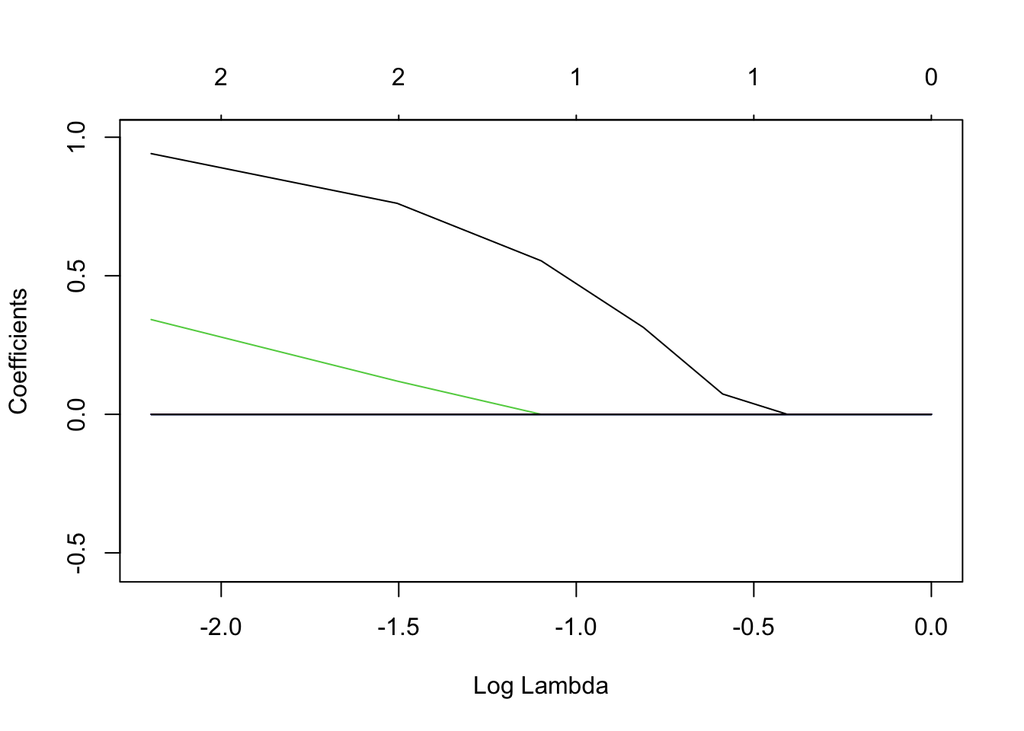

```r
plot(model_lasso, xvar = 'lambda', label = TRUE)
```

#### Изменение коэффициентов в зависимости от величины доли объясненной дисперсии

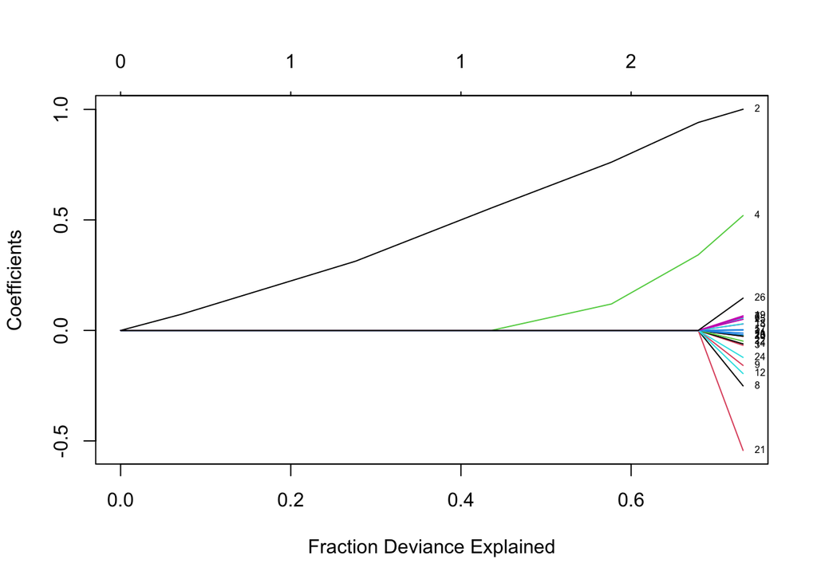

```r
plot(model_lasso, xvar = 'dev', label = TRUE)
```

#### Изменение коэффициентов в зависимости от суммарного штрафа (сумма моделей)

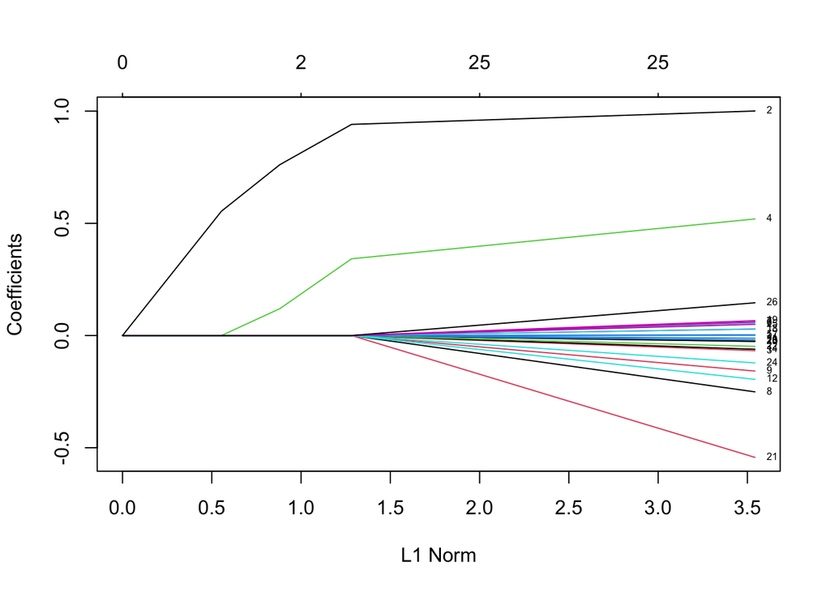

```r
plot(model_lasso, xvar = 'norm', label = TRUE)
```

### 3.1.4 Кросс-валидация

Найдем лямду, которая минимизирует MSE:

```r
model_cv <- cv.glmnet(X, # матрица иксов
                      data$log_price, # зависимая переменная
                      alpha=1, # 1 лассо, 0 ридж
                      type.measure ="mse") # метрика качества
```

График зависимости MSE в кросс-валидации в зависимости от лямд:

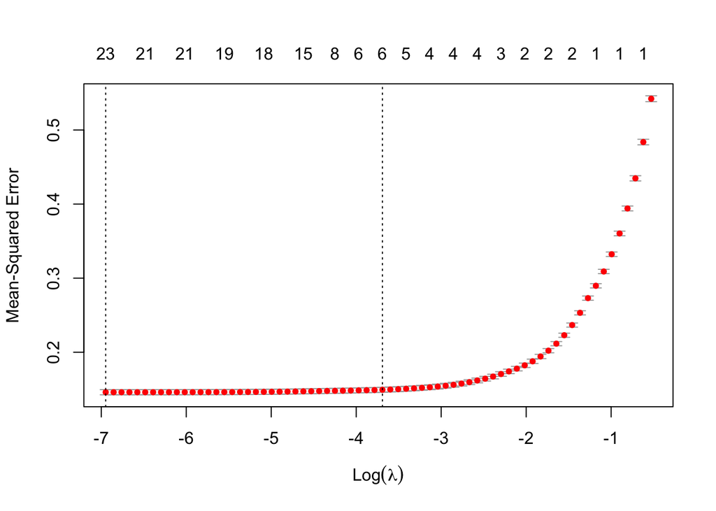

```r
plot(model_cv)
```

Функция `cv.glmnet` расчитывает две лямды:

- лямда, которая минимизирует MSE

```r
model_cv$lambda.min
```

```
## [1] 0.0009607159
```

- лямда, которая на одно стандартное отклонение больше, чем та, которая минимизирует MSE

```r
model_cv$lambda.1se
```

```
## [1] 0.02493081
```

## 3.2 Ridge

С ридж всё аналогично, набор переменных и лямбд будем использовать те же, поэтому шаг с подготовкой можем пропустить.

### 3.2.1 Оценивание

```r
model_ridge <- glmnet(x=X, # матрица иксов
                      y=data$log_price, # зависимая переменная
                      alpha = 0, # 1 лассо, 0 ридж
                      lambda = lambdas) # вектор лямбд
```

### 3.1.3 Диагностика

```r
print(model_ridge)
```

```
##
## Call:  glmnet(x = X, y = data$log_price, alpha = 0, lambda = lambdas)
##
##    Df  %Dev Lambda
## 1  25 63.20 1.0000
## 2  25 64.33 0.8889
## 3  25 65.46 0.7778
## 4  25 66.59 0.6667
## 5  25 67.72 0.5556
## 6  25 68.83 0.4444
## 7  25 69.93 0.3333
## 8  25 71.04 0.2222
## 9  25 72.18 0.1111
## 10 25 73.15 0.0000
```

- Df – количество ненулевых коэффициентов
- %Dev – процент (нулевого) объясненного отклонения
- Lambda – значение параметра регуляризации

```r
coef(model_ridge, lambdas[3])
```

```
## 27 x 1 sparse Matrix of class "dgCMatrix"
##                              s1
## (Intercept)          8.38517885
## (Intercept)          .
## log_total_area       0.58836764
## discrim_proxy       -0.09137422
## Mos_center           0.27578976
## Akimanka_rajon       0.27391031
## Hamovniki_rajon      0.25436802
## Tverskoj_rajon       0.28278370
## Taganskij_rajon     -0.01813180
## Krasnoselskij_rajon  0.06609075
## Mesanskij_rajon      0.21742173
## Zamoskvorece_rajon   0.20567341
## Basmannyj_rajon      0.05976730
## Arbat_rajon          0.26650326
## first_floor         -0.09193410
## one_room            -0.17011716
## two_rooms           -0.04049721
## three_rooms          0.13482484
## four_and_over_rooms  0.24528087
## starii_fond          0.13430146
## blochnii            -0.07072746
## derevjannii         -0.48947157
## kirpichnii          -0.05080074
## monolitnii           0.03244421
## panelnii            -0.13642449
## stalinskii           0.06640182
## repair               0.14574420
```

#### Изменение коэффициентов в зависимости от размера штрафов (lambda)

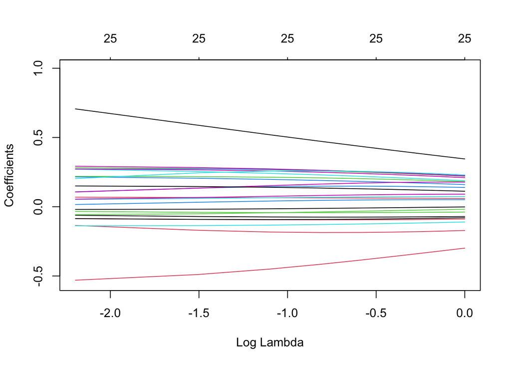

```r
plot(model_ridge, xvar = 'lambda', label = TRUE)
```

#### Изменение коэффициентов в зависимости от величины доли объясненной дисперсии

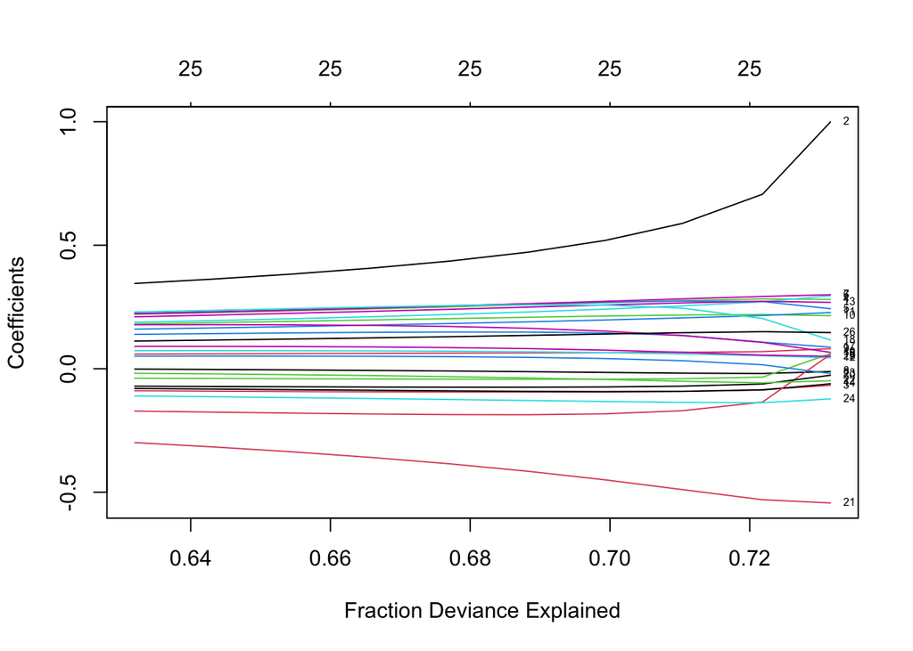

```r
plot(model_ridge, xvar = 'dev', label = TRUE)
```